# Practical assignments during the class

Author

Pedro Henrique Vargas de Araujo

## Introdução

A aula 2 do curso de Genética Estatistica do PPG-GMP versa sobre temas básicos de inferencia estatística: Iniciando pela base de estatistica e probabilidade básica: esperança, correlação, covariança, Teorema do Limite Central, tratamento estatistico de variáveis discretas e contínuas, além de ferramentas do R que podem ser utilizadas para fazer a análise descritiva e exploratória dos dados, além de gráficos que podem ser usados. O objetivo dessas práticas foi revisar esses conceitos, por meio da resolução de problemas praticos em R.

## Primeiro Exercício

### Desenvolvimento

Para começar as simulações, é necessário primeiro configurar um vetor com o tamanho das amostras, e definindo a seed de amostragem:

```r
#setting seed
set.seed(17765673)
#sample sizes vector
samples <- c(10, 100, 1000)
```

como todas as simulações e gráficos serão feitos para os três tamanhos amostrais, uma estratégia interessante é usar o loop for para repetir as operações para cada um deles, para isso podemos fazer:

```r
for (sample in samples) {
  G <- rnorm(sample, mean = 0, sd = 1)
  E <- rnorm(sample, mean = 0, sd = 1)
  P <- G + E
```

Com isso o R vai fazer cada uma das amostragens para cada tamanho amostral, seguindo, podemos calculas os indicadores da estatistica descritiva para termos uma noção da distribuição:

```r
 # mean and variance
  medias <- c(mean(P), mean(G), mean(E))
  variancias <- c(var(P), var(G), var(E))
  #printing resuls
  print(paste("size: ", sample))
  print(paste("mean :", medias))
  print(paste("variance :", variancias))
```

como está dentro do loop, a função printará valores para cada uma dos componentes e tamanhos amostrais:

```
[1] "size:  10"
[1] "mean : -0.423205268045488" "mean : -0.529566883837555"
[3] "mean : 0.106361615792067"
[1] "variance : 2.03400155156965"  "variance : 0.679034532174472"
[3] "variance : 1.8826090035361"
[1] "size:  100"
[1] "mean : -0.209405762372165"  "mean : -0.122471995706878"
[3] "mean : -0.0869337666652874"
[1] "variance : 1.85513030256033"  "variance : 0.983651674296516"
[3] "variance : 1.08987236930035"
[1] "size:  1000"
[1] "mean : 0.010243974055284"   "mean : 0.0165128772838151"
[3] "mean : -0.0062689032285311"
[1] "variance : 2.01515490756094"  "variance : 1.05087913017721"
[3] "variance : 0.964768230678785"
```

Agora podemos fazer os gráficos pedidos:

```r
  # Histogram
hist(P, main = paste("Histogram of P", sample))
```

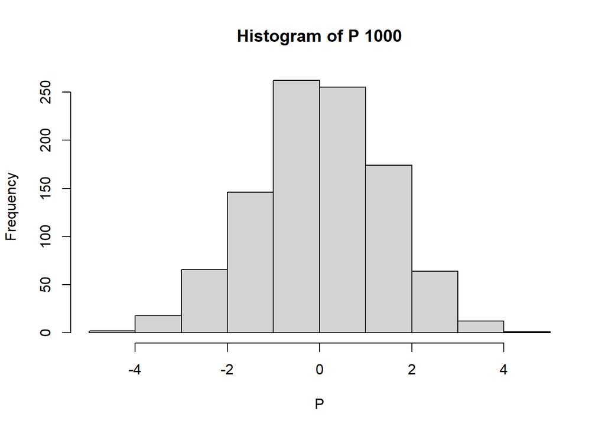

```r
# Density
plot(density(P), main = paste("Density", sample))
```

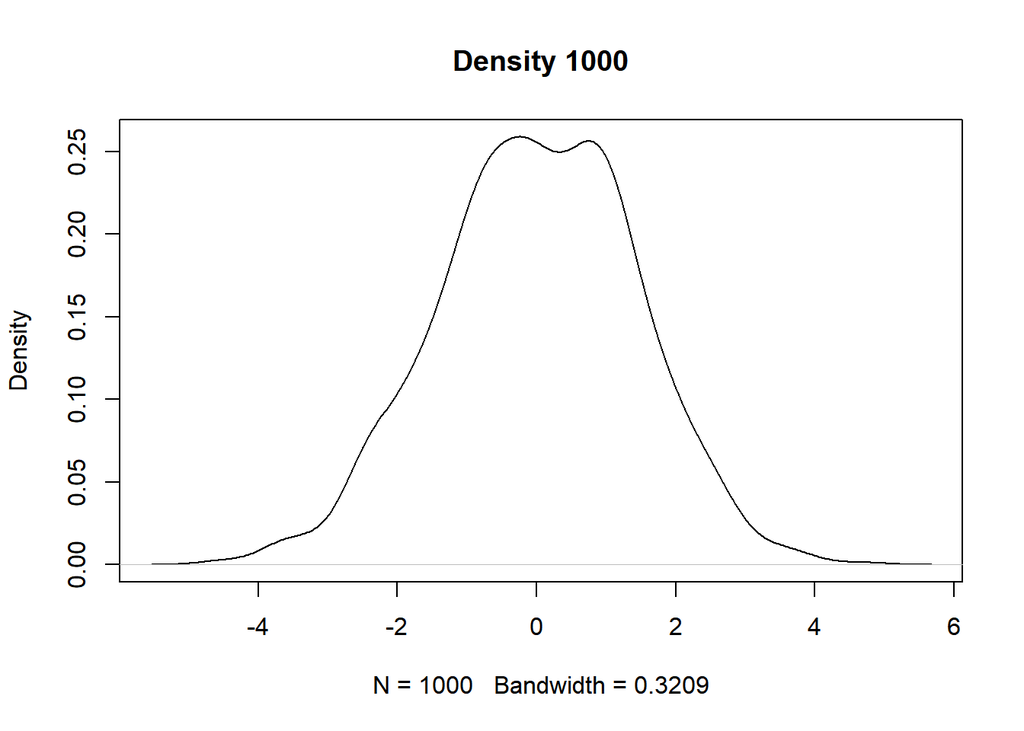

```r
# Boxplot
boxplot(P, G, E,
        names = c("P", "G", "E"),
        main = paste("Boxplot", sample )
        )
```

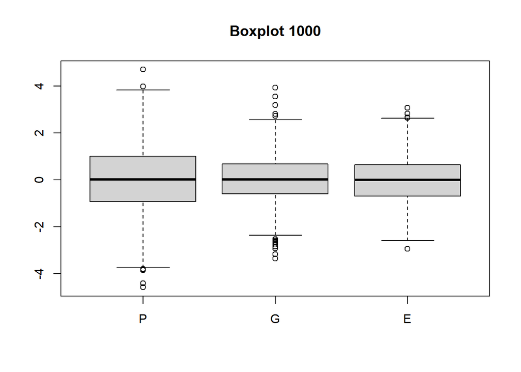

```r
# Scatter plot
plot(G, P,
     main = paste("P x G", sample),
     xlab = "G", ylab = "P",
     pch = 19)
```

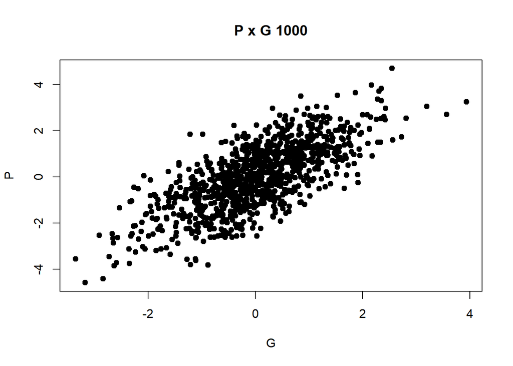

Não aparece aqui nessa apresentação, mas também são gerados graficos para 100 e para 10, por estarem dentro do for loop.

### Conclusão

Este exercício permitiu revisar, de forma prática, conceitos básicos de estatística aplicados à genética quantitativa, além de evidenciar que amostras maiores produzem estimativas mais estáveis e próximas do esperado.

Os gráficos auxiliaram na visualização das distribuições e relações entre as variáveis, enquanto o uso do R se mostrou essencial para a análise e interpretação dos dados.

## Segundo Exercicio

### Desevolvimento

Iniciaremos o código importando a base de dados africana e criando uma subbase filtrando apenas dados do Benin:

```r
#importing dataset
dataset = read.csv("https://raw.githubusercontent.com/mauricioaraujj/Pan_African_Trials_Network/refs/heads/main/data/data.csv",sep = ';')
dim(dataset)
```

```
[1] 27638    42
```

```r
#subseting
data_benin = subset(dataset, env == "E057")
```

Na etapa abaixo, foi feita toda uma análise exploratória dos dados, desde dimensão da base, verificação das variáveis e seus rótulos, até a verificação se as variáveis em estudo tiveram o tipo reconhecido corretamente pelo R e verificação por parcelas perdidas.

```r
#exploring
dim(data_benin)
```

```
[1] 90 42
```

```r
head(data_benin)
```

```
     COUNTRY YEAR  env  gen  loc SEASON rep check PL_EMERG_COUNT PL_EMERG_PCT
4673   Benin 2019 E057 G063 L046      1   1     0              0            0
4674   Benin 2019 E057 G145 L046      1   1     0              0            0
4675   Benin 2019 E057 G142 L046      1   1     0              0            0
4676   Benin 2019 E057 G031 L046      1   1     0              0            0
4677   Benin 2019 E057 G084 L046      1   1     0              0            0
4678   Benin 2019 E057 G059 L046      1   1     0              0            0
     FLW_DAYS FLW_CL PUB_CL NDM LOD PODDING_MAT Pod_Shattering PH_R8 W100G   GY
4673       43 Purple  Tawny  99   1           0              0  60.6    18  735
4674       41 Purple  Tawny 104   1           0              0  63.8    18 1241
4675       39 Purple  Tawny 102   1           0              0  49.0    25 1906
4676       53 Purple  Tawny 116   1           0              0  57.2    13 2367
4677       46 Purple  Tawny 113   1           0              0  66.8    14 1614
4678       46 Purple  Tawny  92   1           0              0  51.4    16 1254
     R6_BB_Sev R6_BP_Sev R6_BS_Sev R6_BTS_Sev R6_CLB_Sev R6_DM_Sev R6_MLS_Sev
```

[output cut: 27 more lines]

```r
#viewing if the type of the variables of interest is correct
str(data_benin[c("GY","NDM" ,"PH_R8")])
```

```
'data.frame':   90 obs. of  3 variables:
 $ GY   : num  735 1241 1906 2367 1614 ...
 $ NDM  : int  99 104 102 116 113 92 113 102 104 102 ...
 $ PH_R8: num  60.6 63.8 49 57.2 66.8 51.4 75.4 54.2 60.8 59 ...
```

```r
#checking for viewing if there is missing data
table(data_benin$rep, data_benin$gen)
```

```
    G003 G023 G031 G059 G060 G061 G062 G063 G078 G079 G080 G081 G082 G083 G084
  1    1    1    1    1    1    1    1    1    1    1    1    1    1    1    1
  2    1    1    1    1    1    1    1    1    1    1    1    1    1    1    1
  3    1    1    1    1    1    1    1    1    1    1    1    1    1    1    1

    G089 G092 G125 G140 G142 G145 G146 G156 G158 G207 G208 G215 G233 G237 G246
  1    1    1    1    1    1    1    1    1    1    1    1    1    1    1    1
  2    1    1    1    1    1    1    1    1    1    1    1    1    1    1    1
  3    1    1    1    1    1    1    1    1    1    1    1    1    1    1    1
```

Em seguida foi realizada a analise de correlação utilizando a função cor()

```r
#calculating correlation
cor(data_benin[c("GY", "NDM", "PH_R8")])
```

```
             GY        NDM      PH_R8
GY    1.0000000 0.23470234 0.25558821
NDM   0.2347023 1.00000000 0.09604454
PH_R8 0.2555882 0.09604454 1.00000000
```

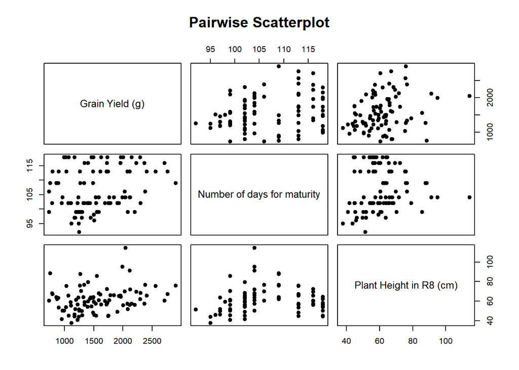

```r
library(ggplot2)
  pairs(data_benin[c("GY","NDM" ,"PH_R8")],
  main = "Pairwise Scatterplot",
  pch = 19,
  labels = c("Grain Yield (g)", "Number of days for maturity", "Plant Height in R8 (cm)")
  )
```

### Conclusão

A análise exploratória dos dados do Benin foi muito interessante permitiu treinar a verificação da estrutura da base, a consistência das variáveis e a ausência de problemas relevantes nos dados, etapas corriqueiras para quem trabalha com análise de dados, o que será muito relevante aos discentes ao longo de suas tragetórias acadêmicas e profissionais.